# 第 A12 章

## 特殊な方法 - たわみ角法

### A12.1 概要

たわみ角法（slope-deflection method）は、あらゆる種類の不静定梁やラーメン構造を解析するために広く用いられている、もう一つの代表的な特殊解法である。この方法では、モーメント分配法と同様に、荷重が構造物に作用したときに節点に集まる部材間の角度は変化しないという観点から、すべての節点が剛であると見なされる。たわみ角法においては、節点の回転角が未知数として扱われる。両端に節点をもつ部材について、端部モーメントは端部の回転角を用いて表現することができる。さらに、静的つり合い条件より、一つの節点に集まる部材の端部モーメントの和はゼロでなければならない。これらの静的つり合い方程式は、未知の節点回転角を処理するために必要な条件を提供し、これらの未知の回転角が求まれば、たわみ角方程式から端部モーメントを計算することができる。たわみ角法の利点については、本章の最後で、方法の説明と問題解決への適用が終わった後に議論する。

### A12.2 たわみ角方程式の誘導

ここでの課題は、梁の端部支持点の変位と、その結果として梁に生じる端部モーメントとの間の関係を決定することである。

図 A12.1a は、両端 1 および 2 で拘束された梁を示している。この梁には荷重が作用しておらず、断面積（または慣性モーメント）は一定であると仮定する。この梁が図 b のように変位したとする。すなわち、両端が角度 $\theta_1$ および $\theta_2$ だけ回転し、さらに元の位置から端部が垂直に変位 $d_1$ および $d_2$ だけ移動し、これにより両端間に相対変位 $\Delta$ が生じる。部材の傾きを表す角度 $\phi$ は $\Delta/L$ に等しい。

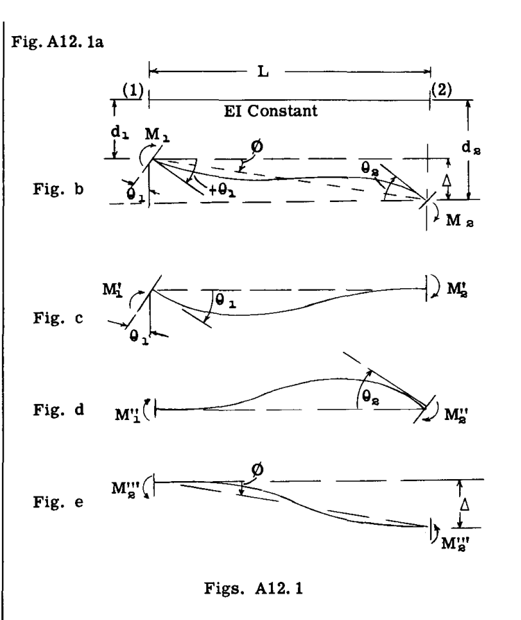

Figs. A12.1

ここでの課題は、端部の傾き $\theta_1$ と $\theta_2$ 、梁の長さ $L$ 、および $EI$ を用いて、 $M_1$ と $M_2$ の方程式を誘導することである。図 c、d、e は、図 b における梁の全たわみが、どのようにして 3 つの独立したたわみに分解されるかを示している。図 c では、端部 (2) が固定されていると見なし、端部 (1) を角度 $\theta_1$ だけ回転させるためにモーメント $M'_1$ が作用している。図 d では、端部 (1) が固定されていると見なし、端部 (2) を角度 $\theta_2$ だけ回転させるためにモーメント $M''_2$ が (2) に作用している。図 e では、両端が固定されていると見なし、端部 (2) が下方へ距離 $\Delta$ だけ変位し、これにより端部モーメント $M'''_1$ と $M'''_2$ が生じている。たわみ角方程式を誘導するにあたり、これら 3 つの梁のたわみを個別に検討し、その結果を足し合わせることで最終的な方程式を得る。図 A12.2 は、図 c を再掲したものである。

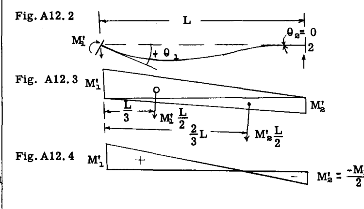

Fig.A12.2, Fig. A12.3, Fig.A12.4

作用するモーメント $M'_1$ は、正（下側繊維に引張）である。端部 (2) は固定されていると仮定されているため、未知のモーメント $M'_2$ が (2) に生じる。図 A12.3 は、2 つの三角形から構成される曲げモーメント図を示している。未知である $M'_2$ も同様に正と仮定する。代数的な計算により $M'_2$ の真の符号が決定されるためである。

たわみ角方程式の誘導には、以下の 2 つのモーメント面積定理を使用する。

1. 梁の弾性曲線上の 2 点間におけるたわみ角の変化は、その 2 点間における $M/EI$ 図の面積の大きさに等しい。
2. 弾性曲線上の点 (A) の、点 (B) における接線からのたわみ（ずれ）の大きさは、(A) と (B) の間にある $M/EI$ 図（荷重として作用する）の、点 A のまわりの 1 次モーメントに等しい。

図 A12.2 において、 $\theta_2 = 0$ であるため、 $\theta_1$ は $M$ 曲線図の面積を $EI$ で割ったものに等しくなる。

$$\theta_1 = \frac{M'_1 L/2}{EI} + \frac{M'_2 L/2}{EI} = \frac{(M'_1 + M'_2) L}{2EI} \quad ---\quad (1)$$

端部 (1) の、(2) における接線からのたわみはゼロであるため、モーメント図の (1) のまわりのモーメントを取り、それをゼロとおく。

$$\left( \frac{M'_1 L}{2EI} \right) \frac{L}{3} + \left( \frac{M'_2 L}{2EI} \right) \frac{2L}{3} = \frac{M'_1 L^2}{6EI} + \frac{M'_2 L^2}{3EI} = 0$$

これより、次式が得られる。

$$-M'_2 = \frac{M'_1}{2} \quad ---\quad (2)$$

図 A12.4 は、モーメント図の実際の形状を示している。

式 (2) の結果を式 (1) に代入すると、次式が得られる。

$$\theta_1 = \frac{M'_1 L}{4EI} \quad \text{または} \quad M'_1 = \frac{4EI\theta_1}{L} \quad ---\quad (3)$$

次に、式 (2) より、次式が得られる。

$$M'_2 = -\frac{2EI\theta_1}{L} \quad ---\quad (4)$$

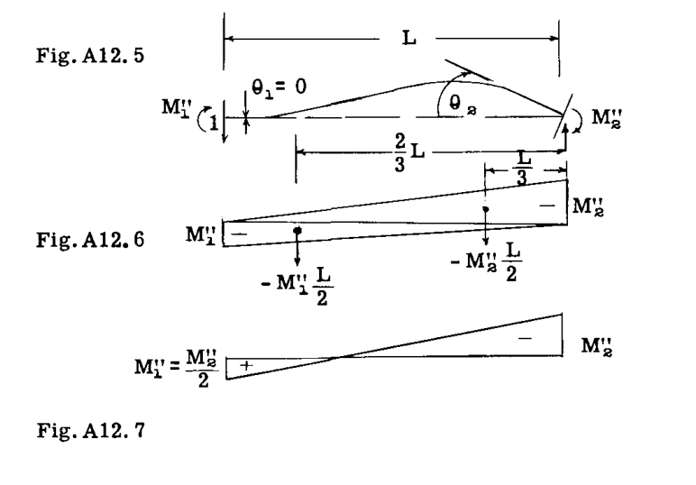

Fig.A12.5, Fig.A12.6, Fig.A12.7

図 A12.6 は、他端 (1) が固定されているときに、端部 (2) を角度 $\theta_2$ だけ回転させるように作用する曲げモーメント $-M''_2$ に対するモーメント図を示している（図 A12.5 を参照）。前述と同様の方法により、次式が得られる。

$$\theta_2 = \frac{-M''_1 L/2}{EI} + \frac{-M''_2 L/2}{EI} = -\frac{(M''_1 + M''_2) L}{2EI} \quad ---\quad (5)$$

2. のまわりの $M/EI$ 図のモーメントを取ると、

$$\left( \frac{M''_1 L}{2EI} \right) \frac{L}{3} + \left( \frac{M''_2 L}{2EI} \right) \frac{2L}{3} = 0$$

図 A12.8 は、梁のたわみの第 3 の部分を示しており、両端が固定されていると仮定して、支持点 (2) が下方へ距離 $\Delta$ だけで変位した状態である。

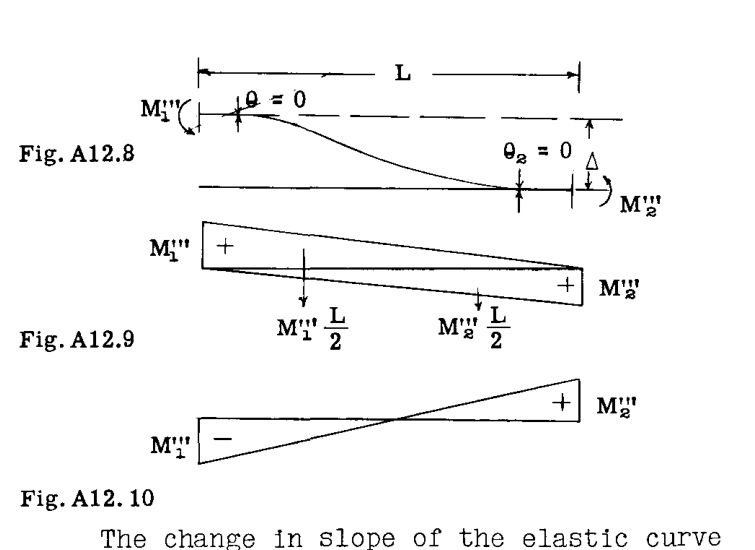

Fig. A12.8, Fig. A12.9, Fig. A12.10

両端の間で弾性曲線の傾きの変化はゼロであるため、モーメント面積定理により、 $M/EI$ 図の面積はゼロに等しくなる。

したがって、

$$\frac{(M'''_1 + M'''_2) L}{2EI} = 0$$

これより、

$$M'''_1 = -M'''_2 \quad ---\quad (9)$$

たわみ定理より、

$$\frac{M'''_1 L}{2EI} \left( \frac{2}{3}L \right) + \frac{M'''_2 L}{2EI} \left( \frac{L}{3} \right) = -\Delta \quad ---\quad (10)$$

式 (9) を式 (10) に代入すると、

$$M'''_1 = -\frac{6EI\Delta}{L^2} \quad ---\quad (11)$$

$$M'''_2 = +\frac{6EI\Delta}{L^2} \quad ---\quad (12)$$

たわみ $\theta_1, \theta_2$ および $\Delta$ の複合的な影響は、それぞれの結果を足し合わせることで得られる。

$$M_{1-2} = M'_1 + M''_1 + M'''_1 = \frac{2EI}{L} (2\theta_1 + \theta_2 - 3\Delta/L)$$

$K = \frac{EI}{L}$ および $\phi = \Delta/L$ とおくと、

$$\text{したがって、} \quad M_{1-2} = 2K(2\theta_1 + \theta_2 - 3\phi) \quad ---\quad (13)$$

$$\text{および} \quad M_{2-1} = -2K(2\theta_2 + \theta_1 - 3\phi) \quad ---\quad (14)$$

支持点の変位によるこれらの端部モーメントは、梁が固定端としてみなされたときに作用する任意の荷重によるモーメントに加えられなければならない。これらの固定端モーメントを $M_{F1}$ および $M_{F2}$ と表記する。このとき、方程式 (13) および (14) は、これらのモーメントを含めて以下のように書くことができる。

$$M_{1-2} = 2K(2\theta_1 + \theta_2 - 3\phi) - M_{F1} \quad ---\quad (15)$$

$$M_{2-1} = -2K(2\theta_2 + \theta_1 - 3\phi) - M_{F2} \quad ---\quad (16)$$

### 修正された符号規約

式 (15) および (16) は、曲げモーメントに関する従来の符号規約を用いて展開された。一般に、第 A11 章のモーメント分配法で使用されたような静的な符号規約を使用することには利点がある。したがって、本章では以下の符号規約を使用する。

1. 節点または部材の回転は、時計回りに回転する場合を正とする。
2. 端部モーメントは、部材の端部を**時計回り**に回転させようとする場合、または節点を**反時計回り**に回転させようとする場合を正とする。

この採用された符号規約は、モーメント分配法で採用されたものと同じである（A11.2 節を参照）。

式 (15) および (16) をこの新しい符号規約に合わせて修正すると、以下のようになる。

$$M_{1-2} = 2K(2\theta_1 + \theta_2 - 3\phi) + M_{F1} \quad ---\quad (17)$$

$$M_{2-1} = 2K(2\theta_2 + \theta_1 - 3\phi) + M_{F2} \quad ---\quad (18)$$

式 (17) および (18) は、たわみ角方程式と呼ばれ、ここで $K = EI/L$ および $\phi = \Delta/L$ である。

支持点の沈下や横方向の移動がない場合、 $\Delta = 0$ となり、式 (17) および (18) は次のようになる。

$$M_{1-2} = 2K(2\theta_1 + \theta_2) + M_{F1} \quad ---\quad (18a)$$

$$M_{2-1} = 2K(2\theta_2 + \theta_1) + M_{F2} \quad ---\quad (18b)$$

### A12.3 ピン接合端のたわみ角方程式

梁 1-2 の端部 (2) が単純支持されている、すなわちピン接合されている場合を考える。これは $M_{2-1}$ がゼロであることを意味する。したがって、式 (18) をゼロとおくことができる。

$$M_{2-1} = 2K(2\theta_2 + \theta_1 - 3\phi) + M_{F2} = 0$$

これより、

$$2K\theta_2 = -K\theta_1 + 3K\phi - 0.5M_{F2}$$

この値を式 (17) に代入すると、

$$M_{1-2} = 3K(\theta_1 - \phi) + M_{F1-2} - 0.5M_{F2-1} \quad ---\quad (19)$$

### A12.4 例題

#### 問題 1

図 A12.11 は、端部 (1) と (3) で固定され、図に示すように横荷重を受ける 2 径間連続梁を示している。点 1、2、3 における曲げモーメントを求める。各部材の $I$ の相対値を以下に示す。

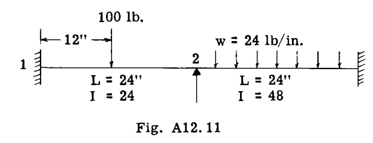

Fig. A12.11

#### 解答

作用荷重による固定端モーメントの計算：

$$M_{F1-2} = -PL/8 = -100 \times 24/8 = -300 \text{ in. lb.}$$

$$M_{F2-1} = PL/8 = 300$$

$$M_{F2-3} = -wL^2/12 = -24 \times 24^2/12 = -1152 \text{ in. lb.}$$

$$M_{F3-2} = 1152$$

$K$ 値： $K = EI/L$ 。 $E$ は一定であるため、1 と見なす。

梁 1-2 について、 $K = I/L = 24/24 = 1$ 梁 2-3 について、 $K = 48/24 = 2$

たわみ角方程式 (18a) および (18b) に代入する（支持点が移動しないため、 $\phi = 0$ ）。

梁 1-2：(1) が固定されているため、 $\theta_1 = 0$ 。

$$M_{1-2} = 2K(2\theta_1 + \theta_2) + M_{F1}$$

$$M_{1-2} = 2 \times 1(0 + \theta_2) - 300$$

$$M_{1-2} = 2\theta_2 - 300 \quad ---\quad (a)$$

$$M_{2-1} = 2K(2\theta_2 + \theta_1) + M_{F2}$$

$$M_{2-1} = 2 \times 1(2\theta_2 + 0) + 300$$

$$M_{2-1} = 4\theta_2 + 300 \quad ---\quad (b)$$

梁 2-3：(3) が固定されているため、 $\theta_3 = 0$ 。

$$M_{2-3} = 2K(2\theta_2 + \theta_3) + M_{F2}$$

$$M_{2-3} = 2 \times 2(2\theta_2 + 0) - 1152$$

$$M_{2-3} = 8\theta_2 - 1152 \quad ---\quad (c)$$

$$M_{3-2} = 2K(2\theta_3 + \theta_2) + M_{F3}$$

$$M_{3-2} = 2 \times 2(0 + \theta_2) + 1152$$

$$M_{3-2} = 4\theta_2 + 1152 \quad ---\quad (d)$$

静的つり合い条件より、節点 (2) において $\Sigma M = 0$ である。

したがって、

$$M_{2-1} + M_{2-3} = 0$$

式 (b) と (c) を代入すると、

$$4\theta_2 + 300 + 8\theta_2 - 1152 = 0$$

これより、

$$\theta_2 = 71$$

$\theta_2$ が既知となったため、これを式 (a)、(b)、(c)、(d) に代入して、最終的な端部モーメントを以下のように求めることができる。

$$M_{1-2} = 2 \times 71 - 300 = -158 \text{ in. lb.}$$

$$M_{2-1} = 4 \times 71 + 300 = 584$$

$$M_{2-3} = 8 \times 71 - 1152 = -584$$

$$M_{3-2} = 4 \times 71 + 1152 = 1436$$

得られたモーメントの符号を従来の曲げモーメントの符号慣用に変換すると、以下のようになる。

$$M_{1-2} = -158, \quad M_{2-1} = M_{2-3} = -584, \quad M_{3-2} = -1436$$

#### 例題 2

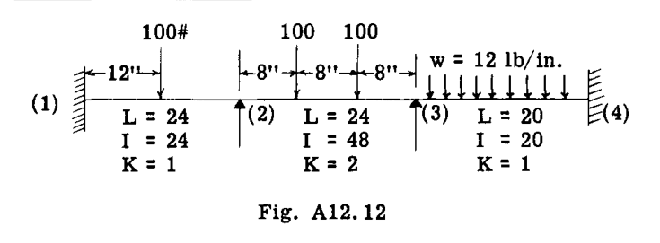

Fig. A12.12

図 A12.12 は、点 (1) と (4) で固定された、荷重を受ける 3 径間梁を示している。この (1) と (4) における固定により、 $\theta_1$ と $\theta_4$ はゼロになる。

固定端モーメント：

$$M_{F1-2} = -PL/8 = -100 \times 24/8 = -300,$$

$$M_{F2-1} = 300$$

$$M_{F2-3} = -(100 \times 8 \times 16^2/24^2) + (100 \times 16 \times 8^2/24^2) = -534$$

$$M_{F3-2} = 534$$

$$M_{F3-4} = -wL^2/12 = -12 \times 20^2/12 = -400,$$

$$M_{F4-3} = 400$$

たわみ角方程式（ $\phi = 0$ ）

$$M_{1-2} = 2 \times 1(0 + \theta_2) - 300 = 2\theta_2 - 300 \quad ---\quad (a)$$

$$M_{2-1} = 2 \times 1(2\theta_2 + 0) + 300 = 4\theta_2 + 300 \quad ---\quad (b)$$

$$M_{2-3} = 2 \times 2(2\theta_2 + \theta_3) - 534 = 8\theta_2 + 4\theta_3 - 534 \quad ---\quad (c)$$

$$M_{3-2} = 2 \times 2(2\theta_3 + \theta_2) + 534 = 8\theta_3 + 4\theta_2 + 534 \quad ---\quad (d)$$

$$M_{3-4} = 2 \times 1(2\theta_3 + 0) - 400 = 4\theta_3 - 400 \quad ---\quad (e)$$

$$M_{4-3} = 2 \times 1(0 + \theta_3) + 400 = 2\theta_3 + 400 \quad ---\quad (f)$$

節点モーメントつり合い方程式：

節点 (2)

$$M_{2-1} + M_{2-3} = 0$$

これより、

$$4\theta_2 + 300 + 8\theta_2 + 4\theta_3 - 534 = 0 \quad \text{または}$$

$$12\theta_2 + 4\theta_3 - 234 = 0 \quad ---\quad (g)$$

節点 (3)

$$M_{3-2} + M_{3-4} = 0$$

これより、

$$8\theta_3 + 4\theta_2 + 534 + 4\theta_3 - 400 = 0 \quad \text{または}$$

$$12\theta_3 + 4\theta_2 + 134 = 0 \quad ---\quad (h)$$

式 (g) および (h) を $\theta_2$ と $\theta_3$ について解くと、以下が得られる。

$$\theta_2 = 26.15, \quad \theta_3 = -19.9$$

式 (a) から (f) にこれらを代入して、最終的な端部モーメントを求める。

$$M_{1-2} = 2\theta_2 - 300 = 2 \times 26.15 - 300 = -247.7 \text{ in. lb.}$$

$$M_{2-1} = 4\theta_2 + 300 = 4 \times 26.15 + 300 = 404.6$$

$$M_{2-3} = 8\theta_2 + 4\theta_3 - 534 = 8 \times 26.15 + 4 \times (-19.9) - 534 = -404.6$$

$$M_{3-2} = 8\theta_3 + 4\theta_2 + 534 = 8 \times (-19.9) + 4 \times 26.15 + 534 = 479.4$$

$$M_{3-4} = 4\theta_3 - 400 = 4 \times (-19.9) - 400 = -479.4$$

$$M_{4-3} = 2\theta_3 + 400 = 2 \times (-19.9) + 400 = 360.2$$

（注意：学生はこれらを従来のモーメント符号に変換し、完全な曲げモーメント図を描く必要がある。）

#### 例題 3 単純支持をもつ梁

図 A12.13 は、点 (1) と (4) にピン支持をもつ、荷重を受けた 3 径間連続梁を示しており、これは $M_{1-2}$ および $M_{4-3}$ が 0 であることを意味する。支持点 (2) および (3) におけるモーメントを決定する。

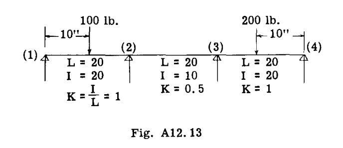

Fig. A12.13

#### 解答

固定端モーメント：

$$M_{F1-2} = -PL/8 = -100 \times 20/8 = -250, \quad M_{F2-1} = 250$$

$$M_{F2-3} = M_{F3-2} = 0 \quad \text{（径間 2-3 に荷重なし）}$$

$$M_{F3-4} = -PL/8 = -200 \times 20/8 = -500, \quad M_{F4-3} = 500$$

たわみ角方程式：

1. と (4) の支持点はピン接合（または自由に回転できる）であるため、 $M_{2-1}$ および $M_{3-4}$ の方程式を書くために式 (19) を使用する（ $\phi$ はゼロ）。

$$M_{2-1} = 3K\theta_2 + M_{F2-1} - 0.5M_{F1-2}$$

$$M_{2-1} = 3 \times 1 \times \theta_2 + 250 - 0.5(-250) = 3\theta_2 + 375 \quad ---\quad (a)$$

$$M_{3-4} = 3K\theta_3 + M_{F3-4} - 0.5M_{F4-3}$$

$$M_{3-4} = 3 \times 1 \times \theta_3 - 500 - 0.5(500) = 3\theta_3 - 750 \quad ---\quad (b)$$

式 (18a) および (18b) を使用して代入すると、

$$M_{2-3} = 2K(2\theta_2 + \theta_3) + M_{F2-3}$$

$$M_{2-3} = 2 \times 0.5(2\theta_2 + \theta_3) + 0 = 2\theta_2 + \theta_3 \quad ---\quad (c)$$

$$M_{3-2} = 2K(2\theta_3 + \theta_2) + M_{F3-2}$$

$$M_{3-2} = 2 \times 0.5(2\theta_3 + \theta_2) + 0 = 2\theta_3 + \theta_2 \quad ---\quad (d)$$

節点の静的つり合い条件より、

節点 (2) $M_{2-1} + M_{2-3} = 0$

代入すると、

$$3\theta_2 + 375 + 2\theta_2 + \theta_3 = 0$$

$$\text{または} \quad 5\theta_2 + \theta_3 + 375 = 0 \quad ---\quad (e)$$

節点 (3) $M_{3-2} + M_{3-4} = 0$

$$2\theta_3 + \theta_2 + 3\theta_3 - 750 = 0$$

$$\text{または} \quad 5\theta_3 + \theta_2 - 750 = 0 \quad ---\quad (f)$$

式 (e) および (f) を $\theta_2$ と $\theta_3$ について解くと、以下が得られる。

$$\theta_2 = -109.4, \quad \theta_3 = 172$$

端部 (2) および (3) におけるモーメントは、式 (a) から (d) に代入することで求めることができる。

$$M_{2-1} = 3\theta_2 + 375 = 3(-109.4) + 375 = 46.8 \text{ in. lb.}$$

$$M_{2-3} = 2\theta_2 + \theta_3 = 2(-109.4) + 172 = -46.8$$

$$M_{3-2} = 2\theta_3 + \theta_2 = 2 \times 172 + (-109.4) = 234$$

$$M_{3-4} = 3\theta_3 - 750 = 3 \times 172 - 750 = -234$$

### A12.5 沈下を伴う支持点をもつ連続梁

飛行機の可動制御面、すなわち昇降舵（elevator）、方向舵（rudder）、補助翼（aileron）は、それぞれ安定板、垂直尾翼、主翼の複数の点に取り付けられている。これらの支持面は通常片持ち構造であるため、可動制御面の支持点は変位を受け、これにより連続梁に沈下またはたわみが生じる。たわみ角方程式は、以下の例題に示すように、この支持点の変位を考慮することができる。

#### 例題

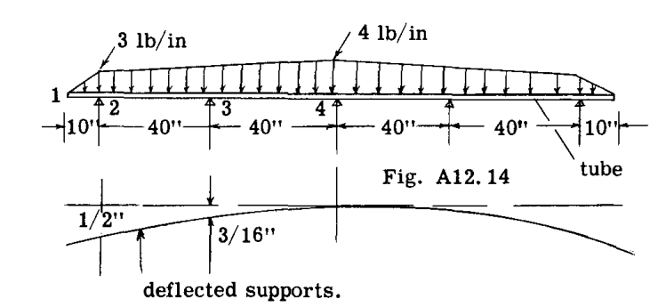

Fig. A12.14, Fig. A12.15

図 A12.14 は、図に示すように 5 つの反力点においてたわみを生じる安定板構造に取り付けられた昇降舵（エレベーター）梁の代表例である。このエレベーター梁は、サイズ $1\text{-}1/4 \text{ - } .049$ の丸アルミニウム管である。この管の慣性モーメント（ $I$ ）は $0.03339$ であり、材料の縦弾性係数（ $E$ ）は 1000 万 psi である。エレベーター梁にかかる空気荷重は、図 A12.14 に示すように変化する。

図 A12.15 は、たわみを生じた支持構造の形状を示しており、これは支持点 (2) および (3) が図に示す距離だけ下方へ移動することを意味している。課題は、横荷重の作用と支持点の沈下が組み合わさった状態における、支持点での曲げモーメントを決定することである。

#### 解答

固定端モーメントの計算：

図 a に示すような台形荷重について、固定端モーメントは以下の通りである。

$$M_{1-2} = -\frac{L^2}{60} (5u + 2v)$$

$$M_{2-1} = \frac{L^2}{60} (5u + 3v)$$

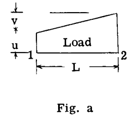

Fig. a

図 A12.14 に示されている荷重の値をこれらの方程式に代入すると、

$$M_{F2-3} = -\frac{40^2}{60} (5 \times 3 + 1) = -426 \text{ in. lb.}$$

$$M_{F3-2} = \frac{40^2}{60} (5 \times 3 + 1.5) = 440$$

$$M_{F3-4} = -\frac{40^2}{60} (5 \times 3.5 + 1) = -494$$

$$M_{F4-3} = \frac{40^2}{60} (5 \times 3.5 + 1.5) = 507$$

梁の断面は一定であるため、すべての径間に対する $K$ は以下に等しい。

$$K = EI/L = (10,000,000 \times 0.03339) / 40 = 8347$$

$\phi$ 値の計算：

径間 2-3：支持点 (3) に対する支持点 (2) の沈下 $= (0.5 - .1875) = .3125 \text{ インチ} = \Delta$

$$\phi = -\Delta/L = -.3125/40 = -0.007812 \text{ rad.}$$

（(2) は (3) に対して反時計回りに移動するため、 $\phi$ の符号は負となる。）

径間 3-4： $\Delta = .1875 \text{ インチ}$

$$\phi = -\Delta/L = -.1875/40 = -0.004688 \text{ rad.}$$

梁、外荷重、および支持点の沈下は支持点 (4) に関して対称であるため、(4) における梁の弾性曲線の傾きは水平、すなわちゼロであり、したがって $\theta_4 = 0$ となる。したがって、解析においては構造物の半分のみを考慮すればよい。(2) は片持ちの張り出し部をもつ単純支持点であるため、モーメント $M_{2-1}$ は静定であり、以下のようになる。

$$5 \times 3 \times 3.33 = 50 \text{ in. lb.}$$

したがって、節点 (2) の静的つり合いより、 $M_{2-3}$ は $-50$ でなければならない。

たわみ角方程式 (17) および (18) への代入：

$$M_{2-3} = 2K(2\theta_2 + \theta_3 - 3\phi) + M_{F2-3}$$

$$-50 = 2 \times 8347 [2\theta_2 + \theta_3 - 3(-0.007812)] - 426$$

$$\text{または} \quad 33388\theta_2 + 16694\theta_3 + 15 = 0 \quad ---\quad (1)$$

$$M_{3-2} = 2K(2\theta_3 + \theta_2 - 3\phi) + M_{F3-2} = 2 \times 8347 [2\theta_3 + \theta_2 - 3(-0.007812)] + 440$$

$$\text{これより} \quad M_{3-2} = 33388\theta_3 + 16694\theta_2 + 831 \quad ---\quad (2)$$

$$M_{3-4} = 2K(2\theta_3 + \theta_4 - 3\phi) + M_{F3-4} \quad (\theta_4 = 0)$$

$$M_{3-4} = 2 \times 8347 [2\theta_3 + 0 - 3(-.004688)] - 494$$

$$\text{これより} \quad M_{3-4} = 33388\theta_3 - 259 \quad ---\quad (3)$$

$$M_{4-3} = 2K(2\theta_4 - \theta_3 - 3\phi) + M_{F4-3}$$

$$M_{4-3} = 2 \times 8347 [0 + \theta_3 - 3(-.004688)] + 507$$

$$\text{これより} \quad M_{4-3} = 16694\theta_3 + 742 \quad ---\quad (4)$$

節点 (3) の静的つり合い条件より、

$$M_{3-2} + M_{3-4} = 0$$

したがって、

$$33388\theta_3 + 16694\theta_2 + 831 + 33388\theta_3 - 259 = 0$$

$$\text{これより} \quad 66776\theta_3 + 16694\theta_2 + 572 = 0 \quad ---\quad (5)$$

式 (1) および (5) を $\theta_2$ と $\theta_3$ について解くと、 $\theta_2 = 0.00439$ および $\theta_3 = -0.00967$ が得られる。

これらを式 (2)、(3)、(4) に代入すると、これらの点におけるモーメントが得られる。

$$M_{3-2} = 33388(-.00967) + 16694 \times .00439 + 831 = 582 \text{ in. lb.}$$

$$M_{3-4} = 33883(-.00967) - 259 = -582$$

$$M_{4-3} = 16694(-.00967) + 742 = 580$$

これらの符号を従来の符号規約に変換すると、 $M_2 = -50, M_3 = -582$ 、および $M_4 = -580$ となる。

### A12.6 節点の回転のみを伴う不静定ラーメン

たわみ角法は、あらゆる種類の骨組構造（ラーメン）を解くために使用できる。直線状の連続梁と比較して、ラーメン部材における軸荷重は通常より重要であるが、部材の軸方向変形による節点変位への影響は比較的小さいため、ほとんどの単純な骨組構造では通常無視される。ラーメン構造に適用されるたわみ角法を説明するために、図 A12.16 に示す構造を解く。

#### 例題 1

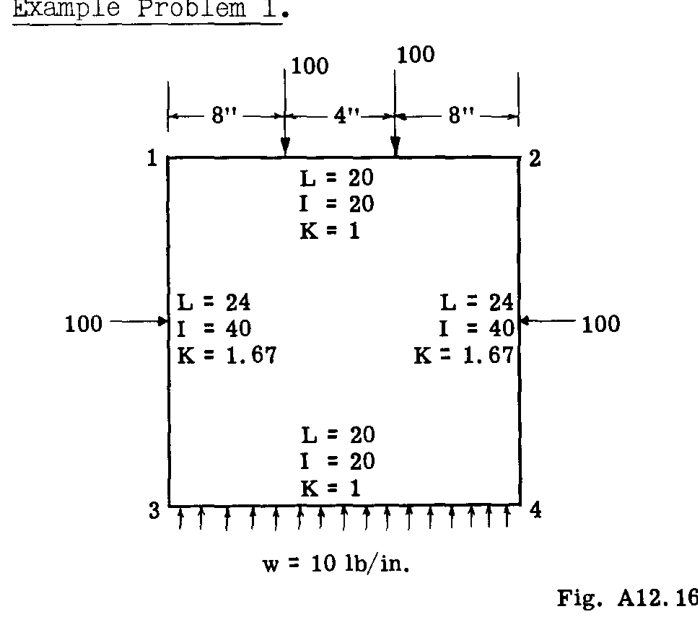

Fig. A12.16

図 A12.16 は、4 つの側面に荷重を受け、構造のつり合いを保っている閉じた矩形ラーメンを示している。このラーメン接合部の曲げモーメントを決定する。

#### 解答

固定端モーメント：

$$M_{F1-2} = -(100 \times 8 \times 12^2)/20^2 + (100 \times 12 \times 8^2)/20^2 = -480$$

$$M_{F2-1} = 480$$

$$M_{F1-3} = 100 \times 24/8 = 300, \quad M_{F3-1} = -300$$

$$M_{F3-4} = 10 \times 20^2/12 = 334, \quad M_{F4-3} = -334$$

荷重の対称性により、 $\theta_1 = -\theta_2$ および $\theta_3 = -\theta_4$ であることがわかり、これにより計算を短縮できる。

たわみ角方程式：

$$M_{1-2} = 2K(2\theta_1 + \theta_2) + M_{F1-2}$$

$$M_{1-2} = 2 \times 1(2\theta_1 - \theta_1) - 480$$

$$M_{1-2} = 2\theta_1 - 480 \quad ---\quad (a)$$

$$M_{1-3} = 2K(2\theta_1 + \theta_3) + M_{F1-3}$$

$$M_{1-3} = 2 \times 1.67(2\theta_1 + \theta_3) + 300$$

$$M_{1-3} = 6.67\theta_1 + 3.33\theta_3 + 300 \quad ---\quad (b)$$

$$M_{3-1} = 2K(2\theta_3 + \theta_1) + M_{F3-1}$$

$$M_{3-1} = 2 \times 1.67(2\theta_3 + \theta_1) - 300$$

$$M_{3-1} = 6.67\theta_3 + 3.33\theta_1 - 300 \quad ---\quad (c)$$

$$M_{3-4} = 2K(2\theta_3 + \theta_4) + M_{F3-4}$$

$$M_{3-4} = 2 \times 1(2\theta_3 - \theta_3) + 334$$

$$M_{3-4} = 2\theta_3 + 334 \quad ---\quad (d)$$

節点の静的方程式：

節点 (1)

$$M_{1-2} + M_{1-3} = 0$$

これより、

$$2\theta_1 - 480 + 6.67\theta_1 + 3.33\theta_3 + 300 = 0$$

$$\text{したがって} \quad 8.67\theta_1 + 3.33\theta_3 - 180 = 0 \quad ---\quad (e)$$

節点 (3)

$$M_{3-1} + M_{3-4} = 0$$

これより、

$$6.67\theta_3 + 3.33\theta_1 - 300 + 2\theta_3 + 334 = 0$$

$$\text{したがって} \quad 8.67\theta_3 + 3.33\theta_1 + 34 = 0 \quad ---\quad (f)$$

式 (e) および (f) を $\theta_1$ と $\theta_3$ について解くと、以下が得られる。

$$\theta_1 = 26.3, \quad \theta_3 = -13.94$$

式 (a) に代入すると、

$$M_{1-2} = 2 \times 26.3 - 480 = -428 \text{ in. lb.}$$

式 (d) に代入すると、

$$M_{3-4} = 2(-13.94) + 334 = 306 \text{ in. lb.}$$

図 A12.17 は、結果として得られる曲げモーメント図を示している。

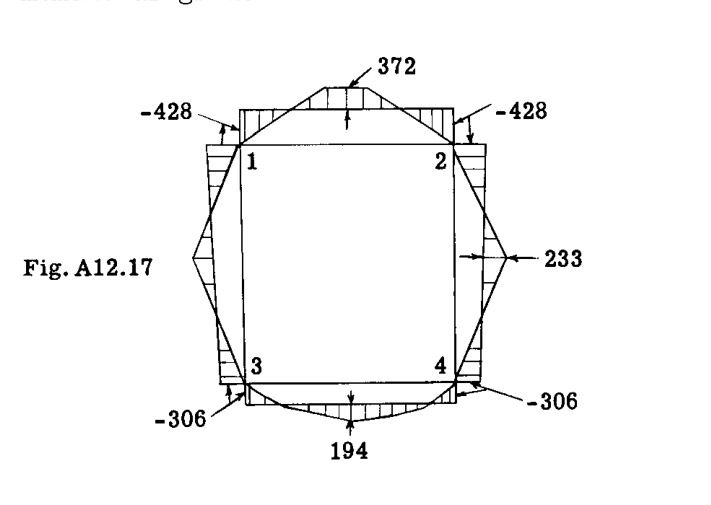

Fig. A12.17

### A12.7 節点変位を伴うラーメン

前述の例題では、節点の回転のみが発生するか、または A12.5 節の例題のように横方向の節点変位が発生した場合でも、これらの変位は既知、すなわちたわみ角における $\phi$ の値が既知であるという条件であった。

しかし、多くの実用的なラーメンでは、図 A12.18 のラーメンのように、節点が未知の変位を被る。たわみ角方程式における $\phi = \Delta/L$ という項は、両端が固定されている場合の部材端部の横方向変位に基づいて誘導された。したがって、外荷重の作用を受ける図 A12.18 において、破線で強調されているように右側へ揺れる（スウェイする）。軸方向変形による節点変位を無視すると、各部材の上端は同じ変位 $\Delta$ だけ移動する。このとき、以下のように書くことができる。

$$\phi_{2-1} = \Delta/L_{1-2}, \quad \phi_{4-3} = \Delta/L_{3-4}, \quad \phi_{6-5} = \Delta/L_{5-6}$$

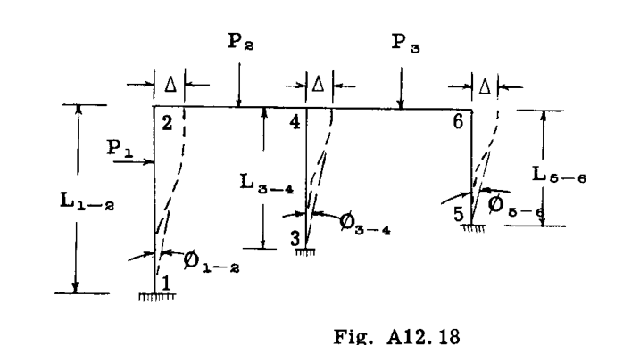

Fig. A12.18

接合部 (1)、(3)、(5) における固定条件により、 $\theta_{1-2} = \theta_{3-4} = \theta_{5-6} = 0$ となる。したがって、未知数は $\theta_{2-1}$ 、 $\theta_{4-3}$ 、 $\theta_{6-5}$ 、および $\Delta$ である。

利用可能な静的な節点方程式は 3 つあり、すなわち以下の通りである。

$$M_{2-1} + M_{2-4} = 0, \quad M_{4-2} + M_{4-6} = 0, \quad \text{および} \quad M_{6-4} + M_{6-5} = 0$$

未知数が 4 つあるため、もう一つの方程式が必要である。この追加の方程式は、垂直部材の自由体に静力学の方程式を適用することによって得られる。図 A12.19 は、その自由体を示している。

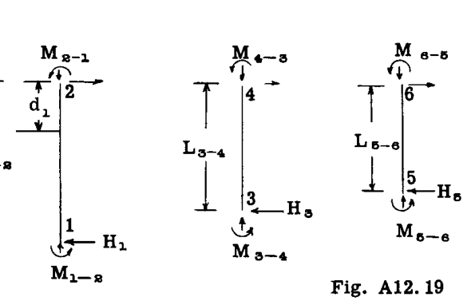

Fig. A12.19

各部材を個別に扱い、上端のまわりのモーメントを取ってゼロとおき、下端における水平反力を解く。その結果は以下の通りである。

$$H_1 = \frac{P_1 d_1}{L_{1-2}} + \frac{M_{2-1} + M_{1-2}}{L_{1-2}}$$

$$H_3 = \frac{M_{4-3} + M_{3-4}}{L_{3-4}}$$

$$H_5 = \frac{M_{6-5} + M_{5-6}}{L_{5-6}}$$

これらの水平反力を用いることで、ラーメン全体に対する静的方程式 $\Sigma H = 0$ を適用することができ、次式が得られる。

$$P_1 - H_1 - H_3 - H_5 = 0 \quad ---\quad (20)$$

式 (20) は一般に**ベント方程式**または**せん断方程式**と呼ばれ、追加の未知数 $\Delta$ を処理するために必要な追加の条件を提供する方程式である。

### A12.8 未知の節点変位を伴うラーメンの例題

#### 例題 1

図 A12.20 は、非対称な荷重を受ける非対称なラーメンを示している。この曲げモーメント曲線を決定する。

#### 解答

各部材の相対慣性モーメントを図中に示す。各部材に隣接して、相対的な $K = I/L$ の値も示されている。

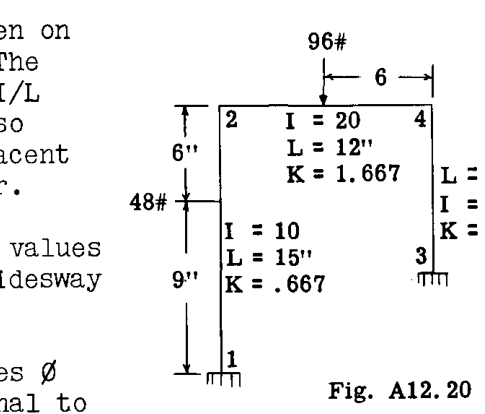

Fig. A12.20, Fig. A12.10

ラーメンの横揺れ（サイドスウェイ）による $\phi$ の相対値：

したがって、

$$\phi_{2-1} = \frac{1}{15} = .0667\phi$$

$$\phi_{4-3} = \frac{1}{10} = 0.10\phi$$

$$\phi_{2-4} = \frac{0}{12} = 0$$

固定端モーメント：

部材 1-2：

$$M_{F1-2} = -(48 \times 6^2 \times 9)/15^2 = -69.12 \text{ in. lb.}$$

$$M_{F2-1} = (48 \times 9^2 \times 6)/15^2 = 103.68$$

部材 2-4：

$$M_{F2-4} = -(96 \times 12)/8 = -144$$

$$M_{F4-2} = 144$$

部材 3-4 は横荷重を受けないため、固定端モーメントはゼロである。

たわみ角方程式は以下の通りである。

$$M_{1-2} = 2K(2\theta_1 + \theta_2 - 3\phi) + M_{F1} \quad ---\quad (17)$$

$$M_{2-1} = 2K(2\theta_2 + \theta_1 - 3\phi) + M_{F2} \quad ---\quad (18)$$

各部材について上記の方程式を書き、支持点においてラーメンが固定されているため $\theta_1$ と $\theta_3$ がゼロであることを考慮すると、以下が得られる。

$$M_{1-2} = 2 \times 0.667(0 + \theta_2 - 3 \times .0667\phi) - 69.12$$

$$M_{1-2} = 1.333\theta_2 - 0.2667\phi - 69.12 \quad ---\quad (a)$$

$$M_{2-1} = 2 \times 0.667(2\theta_2 + 0 - 3 \times .0667\phi) + 103.68$$

$$M_{2-1} = 2.667\theta_2 - 0.2667\phi + 103.68 \quad ---\quad (b)$$

$$M_{2-4} = 2 \times 1.667(2\theta_2 + \theta_4 - 0) - 144$$

$$M_{2-4} = 6.667\theta_2 + 3.333\theta_4 - 144 \quad ---\quad (c)$$

$$M_{4-2} = 2 \times 1.667(2\theta_4 + \theta_2 - 0) + 144$$

$$M_{4-2} = 6.667\theta_4 + 3.333\theta_2 + 144 \quad ---\quad (d)$$

$$M_{3-4} = 2 \times 1(0 + \theta_4 - 3 \times 0.1\phi) + 0$$

$$M_{3-4} = 2\theta_4 - 0.6\phi \quad ---\quad (e)$$

$$M_{4-3} = 2 \times 1(2\theta_4 + 0 - 3 \times 0.1\phi) + 0$$

$$M_{4-3} = 4\theta_4 - 0.6\phi \quad ---\quad (f)$$

つり合い方程式：

節点 (2) $M_{2-1} + M_{2-4} = 0$

代入すると、

$$2.667\theta_2 - 0.2667\phi + 103.68 + 6.667\theta_2 + 3.333\theta_4 - 144 = 0$$

$$\text{これより、} \quad 9.333\theta_2 - 0.2667\phi + 3.333\theta_4 - 40.32 = 0 \quad ---\quad (g)$$

節点 (4) $M_{4-2} + M_{4-3} = 0$

$$6.667\theta_4 + 3.333\theta_2 + 144 + 4\theta_4 - 0.6\phi = 0$$

$$\text{これより、} \quad 10.667\theta_4 + 3.333\theta_2 - 0.6\phi + 144 = 0 \quad ---\quad (h)$$

ベント方程式を記述する（式 20 を参照）。

$$H_1 + H_3 - 48 = 0 \quad ---\quad (i)$$

$H_1$ と $H_3$ を端部モーメントで表すために、図 A12.21 を参照する。

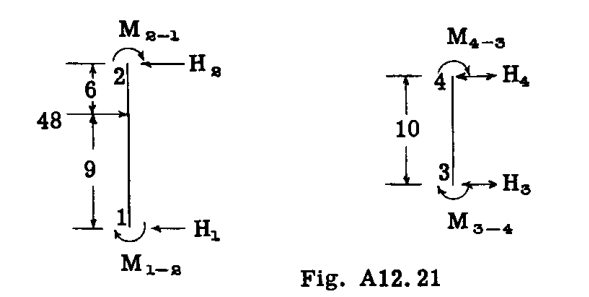

Fig. A12.21

部材 1-2 の自由体について、(2) のまわりのモーメントを取り、ゼロとおく。

$$M_{2-1} + M_{1-2} - 6 \times 48 + 15H_1 = 0$$

$$\text{したがって、} \quad H_1 = \frac{288 - (M_{2-1} + M_{1-2})}{15}$$

式中に $M_{2-1}$ と $M_{1-2}$ の値を代入すると、

$$H_1 = -0.2667\theta_2 + .03555\phi + 16.88 \quad ---\quad (j)$$

部材 3-4 の自由体について、(4) のまわりのモーメントを取り、ゼロとおく。

$$M_{3-4} + M_{4-3} + 10H_3 = 0$$

$$\text{これより、} \quad H_3 = -\frac{(M_{3-4} + M_{4-3})}{10}$$

$M_{3-4}$ と $M_{4-3}$ の値を上記に代入すると、

$$H_3 = -0.6\theta_4 + 0.12\phi \quad ---\quad (k)$$

$H_1$ と $H_3$ の値を式 (i) に代入すると、

$$-0.2667\theta_2 - .6\theta_4 + .1555\phi - 31.12 = 0 \quad ---\quad (l)$$

未知数 $\theta_2$ 、 $\theta_4$ 、および $\phi$ について方程式 (g)、(h)、(l) を解くと、以下が得られる。

$$\phi = 196.9, \quad \theta_2 = 12.17, \quad \theta_4 = -6.22$$

最終的な端部モーメントは、これらの値を式 (a) から (f) に代入することで求めることができる。

$$M_{1-2} = 1.333 \times 12.17 - .2667 \times 196.9 - 69.12 = -105.4 \text{ in. lb.}$$

$$M_{4-2} = 6.667(-6.22) + 3.333 \times 12.17 + 144 = 142.9$$

$$M_{4-3} = 4(-6.22) - 0.6 \times 196.9 = -142.9$$

$$M_{3-4} = 2(-6.22) - 0.6 \times 196.9 = -130.45$$

図 A12.22 は、曲げモーメント図を示している。学生はまた、せん断力図を描き、部材の軸力を求める必要がある。これらの荷重はすべて、ラーメン部材の強度が計算され、ラーメン荷重によって引き起こされる応力と比較される際に必要となるためである。

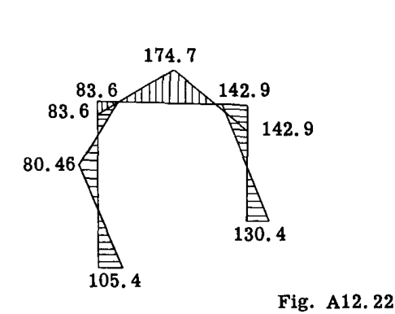

Fig. A12.22

#### 例題 2

図 A12.23 は、示すように対称な等分布荷重を受けるギャーブル（切妻）ラーメンを示している。

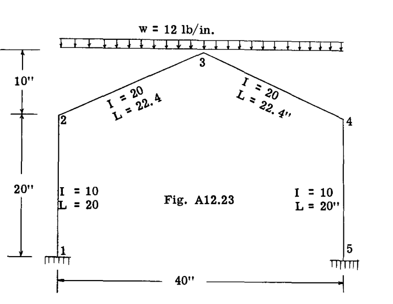

Fig. A12.23

この与えられた荷重における曲げモーメント図を決定する。

#### 解答

相対剛性（ $K$ 値）：

部材 1-2 および 4-5、 $K = 10/20 = 0.5$

部材 2-3 および 4-3、 $K = 20/22.4 = 0.892$

固定端モーメント：

$$M_{F2-3} = wL^2_h/12 = (12 \times 20^2)/12 = -400 \text{ in. lb.}$$

$$M_{F3-2} = 400, \quad M_{F4-3} = 400, \quad M_{F3-4} = -400$$

$\phi$ の相対値：

傾斜した部材があるため、各部材の相対的な横方向たわみは、前の例題のように垂直部材が水平部材に接続されている場合ほど明らかではない。この例題では、接合部 (1) と (5) が固定されている。ラーメンと荷重の対称性により、接合部 (2) と (4) は図 A12.24 に示すように同じ距離 $\Delta$ だけ外側へ移動する。さらに、対称性により、接合部 (3) は垂直方向の移動のみを行う。

図 A12.24 において、点 (2’) から 2-3 に平行で長さが 2-3 に等しい線を引き、点 (3’‘) を決定する。3’’ において 2’-3’’ に垂線を立て、それが (3) を通る垂直線と交わる点が接合部 (3) の最終位置 (3’) となる。2’-3’ の長さは 2-3 に等しい。三角形 3-3’-3’’ において、辺 $3'-3'' = \sqrt{5}\Delta$ である。各部材について $\Delta/L$ で測定される $\phi$ の相対値は、以下のように計算できる。

$$\phi_{1-2} = -\frac{1}{20}\phi = -.05\phi$$

$$\phi_{2-3} = \frac{\sqrt{5}}{22.4}\phi = 0.1\phi$$

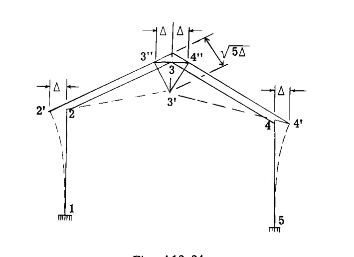

Fig. A12.24

$$\phi_{3-4} = -0.1\phi$$

$$\phi_{4-5} = .05\phi$$

たわみ角方程式への代入：

接合部 (1) と (5) における固定条件により、 $\theta_1 = \theta_5 = 0$ であることがわかっている。また、対称性、または接合部 (3) の垂直移動のみにより、 $\theta_3 = 0$ である。さらに、対称性により、 $\theta_4 = -\theta_2$ である。

$$M_{1-2} = 2K(2\theta_1 + \theta_2 - 3\phi) + M_{F1-2}$$

$$M_{1-2} = 2 \times 0.5(0 + \theta_2 + .05 \times 3\phi) + 0$$

$$M_{1-2} = \theta_2 + 0.15\phi \quad ---\quad (a)$$

$$M_{2-1} = 2K(2\theta_2 + \theta_1 - 3\phi) + M_{F2-1}$$

$$M_{2-1} = 2 \times 0.5(2\theta_2 + .05 \times 3\phi) + 0$$

$$M_{2-1} = 2\theta_2 + 0.15\phi \quad ---\quad (b)$$

$$M_{2-3} = 2K(2\theta_2 + \theta_3 - 3\phi) + M_{F2-3}$$

$$M_{2-3} = 2 \times 0.892(2\theta_2 + 0 - .3 \times 0.1\phi) - 400$$

$$M_{2-3} = 3.568\theta_2 - 0.5352\phi - 400 \quad ---\quad (c)$$

$$M_{3-2} = 2K(2\theta_3 + \theta_2 - 3\phi) + M_{F3-2}$$

$$M_{3-2} = 2 \times .892(0 + \theta_2 - 3 \times 0.1\phi) + 400$$

$$M_{3-2} = 1.784\theta_2 - 0.5352\phi + 400 \quad ---\quad (d)$$

$$M_{3-4} = 2K(2\theta_3 + \theta_4 - 3\phi) + M_{F3-4}$$

$$M_{3-4} = 2 \times .892(0 - \theta_2 + 3 \times 0.1\phi) - 400$$

$$M_{3-4} = -1.784\theta_2 + 0.5352\phi - 400 \quad ---\quad (e)$$

$$M_{4-3} = 2K(2\theta_4 + \theta_3 - 3\phi) + M_{F4-3}$$

$$M_{4-3} = 2 \times .892(-2\theta_2 + 0 + 3 \times 0.1\phi) + 400$$

$$M_{4-3} = -3.568\theta_2 + 0.5352\phi + 400 \quad ---\quad (f)$$

$$M_{4-5} = 2K(2\theta_4 + \theta_5 - 3\phi) + M_{F4-5}$$

$$M_{4-5} = 2 \times 0.5(-2\theta_2 + 0 - 3 \times .05\phi) + 0$$

$$M_{4-5} = -2\theta_2 - 0.15\phi \quad ---\quad (g)$$

$$M_{5-4} = 2K(2\theta_5 + \theta_4 - 3\phi) + M_{F5-4}$$

$$M_{5-4} = 2 \times 0.5(0 - \theta_2 - 3 \times .05\phi) + 0$$

$$M_{5-4} = -\theta_2 - 0.15\phi \quad ---\quad (h)$$

節点 (2) のつり合い方程式：

$$M_{2-1} + M_{2-3} = 0, \quad \text{代入すると}$$

$$2\theta_2 + 0.15\phi + 3.568\theta_2 - 0.5352\phi - 400 = 0$$

$$\text{これより、} \quad 5.568\theta_2 - 0.3852\phi - 400 = 0 \quad ---\quad (i)$$

節点 (3) と (4) における節点つり合い方程式は、独立した方程式を提供しない。なぜなら、たわみ角方程式におけるこれまでの代入において、 $\theta_3$ はすでにゼロとされ、 $\theta_4$ は $-\theta_2$ と等しくされていたためである。

せん断方程式：

対称性により、点 (1) と (5) における水平反力は大きさが等しく方向が逆であるため、静的につり合っている。未知数 $\theta_2$ と $\phi$ の 2 つがあるため、式 (i) とともに使用する別の方程式が必要である。この方程式は、端部 (2) における部材 2-1 の水平反力 $H_{2-1}$ が、端部 (2) における部材 2-3 の水平反力 $H_{2-3}$ と等しく方向が逆でなければならないという条件から得ることができる。

図 A12.25 および 26 は、部材 1-2 および 2-3 の自由体の概略を示している。

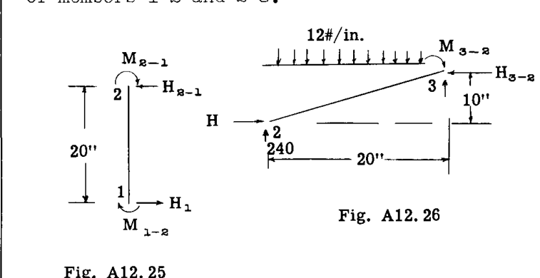

Fig. A12.25, Fig. A12.26

図 A12.25 において、(1) のまわりのモーメントを取り、ゼロとおく。

$$M_{1-2} + M_{2-1} - 20H_{2-1} = 0$$

$$\text{これより、} \quad H_{2-1} = \frac{M_{1-2} + M_{2-1}}{20}$$

また、図 A12.26 において、(3) のまわりのモーメントを取ると、

$$M_{2-3} + M_{3-2} + 240 \times 20 - 20 \times 12 \times 10 - 10H_{2-3} = 0$$

$$\text{これより、} \quad H_{2-3} = \frac{M_{2-3} + M_{3-2} + 2400}{10}$$

せん断方程式 $H_{2-1} = H_{2-3}$ より、次式が得られる。

$$\frac{M_{1-2} + M_{2-1}}{20} = \frac{M_{2-3} + M_{3-2} + 2400}{10}$$

端部モーメントの値を代入すると、

$$\frac{\theta_2 + 0.15\phi + 2\theta_2 + 0.15\phi}{20} = \frac{3.568\theta_2 - 0.5352\phi - 400 + 1.784\theta_2 - 0.5352\phi + 400 + 2400}{10}$$

これより、

$$0.3852\theta_2 - 0.122\phi + 240 = 0 \quad ---\quad (j)$$

$\theta_2$ と $\phi$ について方程式 i と j を解くと、以下が得られる。

$$\phi = 2805, \quad \theta_2 = 265.8$$

これらの値を方程式 (a) から (h) に代入すると、端部モーメントは以下のように得られる。

$$M_{1-2} = \theta_2 + 0.15\phi = 265.8 + 0.15 \times 2805 = 686.5 \text{ in. lb.}$$

$$M_{2-1} = 2\theta_2 + 0.15\phi = 531.6 + 420.7 = 952$$

$$M_{2-3} = 3.568\theta_2 - 0.5352\phi - 400 = 3.568 \times 265.8 - 0.5352 \times 2805 - 400 = -952$$

$$M_{4-3} = 952$$

$$M_{4-5} = -952$$

$$M_{5-4} = -686.5$$

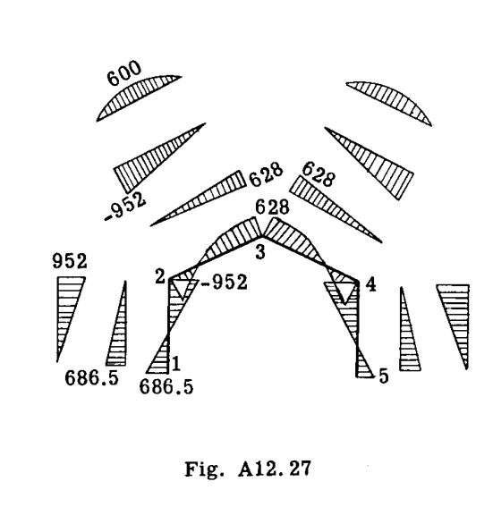

Fig. A12.27

図 A12.27 は、結果として得られる曲げモーメント図を示している。この図は、最初にラーメンの各部材について個別に描かれ、その後、ラーメン上に直接プロットされた複合図を形成するために合算されたものである。せん断力および軸力は、静力学の条件から容易に求められる。モーメント図がわかれば、ラーメンのたわみ形状は容易に計算できる。

### A12.9 たわみ角法に関するコメント

例題の解答は、たわみ角法に 2 つの利点があることを示している。すなわち、(1) 同時に解くべき方程式の数が減少すること、および (2) 容易かつ迅速に定式化できる方程式が提示されることである。

したがって、冗長度の高い構造物（不静定次数の高い構造物）については、たわみ角法が最善の解法として考慮されるべきである。この方法における方程式の解法は、高速計算機による解決のために容易にプログラミングすることができる。

### A12.10 問題

1. 図 A12.28 に示す連続梁について、支持点 A、B、C、D における曲げモーメントを決定せよ。

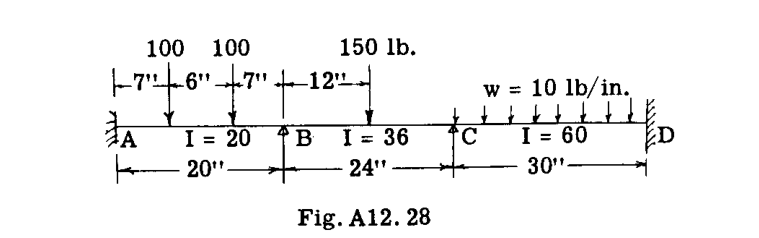

Fig. A12.28

2. 問題 (1) と同様であるが、支持点 A が固定ではなく単純支持されているものとして考慮せよ。
3. 図 A12.29 に示す様々な荷重を受ける構造物について、曲げモーメント図を決定せよ。

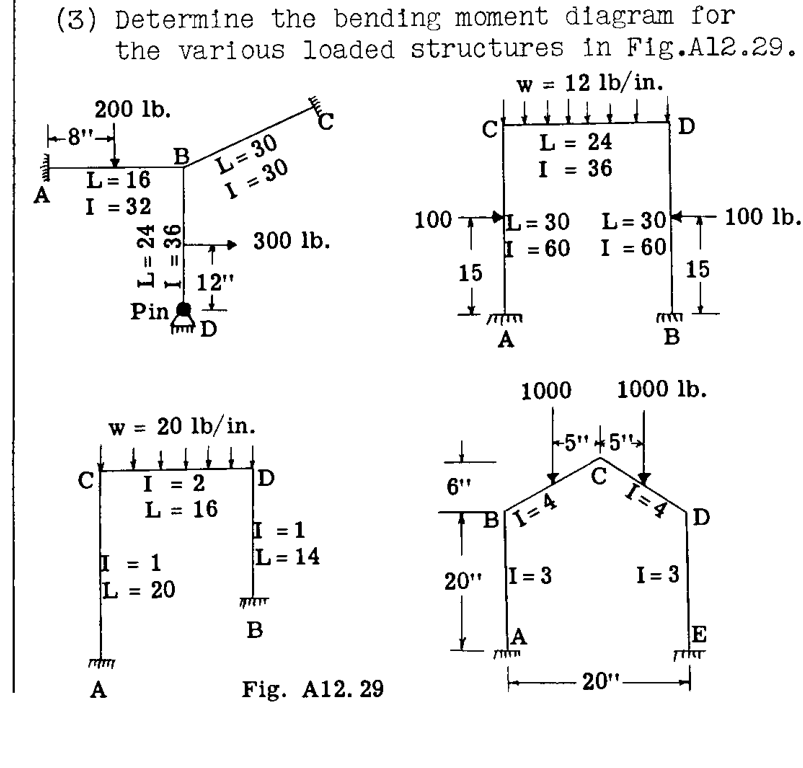

Fig. A12.29